# 📘🔢📏 La Persistence Multiplicative (Relaxée) de Erdös 🧑‍🏫🧮

## Module 1 : Convert integer to list

#### To demonstrate how we converted an integer to a list of digit, we will take **x=4**

We can decompose :

$E = e_0.10^0 + e_1.10^1 + e_2.10^2 + e_3.10^3$

How do we get back $e_i$ ?

$e_3 = \lfloor E*10^{-3} \rfloor$  
$e_2 = \lfloor (E - e_3.10^3)\times10^{-2} \rfloor$  
$e_1 = \lfloor (E - e_3.10^3 - e_2.10^2)\times10^{-1} \rfloor$  
$e_0 = \lfloor (E - e_3.10^3 - e_2.10^2 - e_1.10^1)\times10^{-0} \rfloor$

**Note :** $\lfloor x \rfloor$ stands for "floor of x" (partie entière)

For instance :

- $E = \color{orange}3482$
- $e_3 = \lfloor \color{orange}3482\color{reset}.10^{-3} \rfloor = \lfloor 3,482 \rfloor = \color{red}3$
- $e_2 = \lfloor (\color{orange}3482\color{reset} - \color{red}3\color{reset}.10^{3})\times10^{-2} \rfloor = \lfloor (0482)\times10^{-2} \rfloor = \color{cyan}4$
- $e_1 = \lfloor (\color{orange}3482\color{reset} - \color{red}3\color{reset}.10^{3} - \color{cyan}4.10^{2})\times10^{-1} \rfloor = \lfloor (0082)\times10^{-1} \rfloor = \color{green}8$
- $e_0 = \lfloor (\color{orange}3482\color{reset} - \color{red}3\color{reset}.10^{3} - \color{cyan}4.10^{2} - \color{green}8.10^{1})\times10^{-0} \rfloor = \lfloor (0002)\times10^{-0} \rfloor = \color{purple}2$

#### We can generalize this as an equation

*Initialisation* :  
$e_{x-1} = \lfloor E \times 10^{-(x-1)}\rfloor$  
*Recurse* :  
$e_k = \lfloor (E - \sum_{i=k}^{i=(x-1)}(e_{i}*10^i))*10^{-k} \rfloor \enspace \forall k \in [\![ 0,x-1 ]\!]$

**Note :** It is important to compute the $e_k$ in descending order to compute the sum !

```python
# This method takes in args an integer variable (CpoIntVar)
# and converts it into a list of integers.
def entier_to_list(Entier,model):
    # Le reste du code sert uniquement à mettre en forme la transformation multiplicative sous forme de tableau de chiffres [e0',e1',e2',...,ek']
    new_e= [] # Initializing an empty list
    premier_chiffre = model.floor(Entier*10**(-(x-1))) # Retrieve the biggest order digit of our integer (for instance in "891" we get "8")
    new_e.append(premier_chiffre)
    # k est la puissance de 10 concernée par l'itération
    for k in range (int(x-1),0,-1):
        Puissance_10 = [10**i for i in range(int(x-1),k-1,-1)]
        chiffre = model.floor((Entier - np.dot(new_e,Puissance_10))*10**(-k+1))
        new_e.append(chiffre)
    new_e.reverse() # Reverse the list so we convert it from [ek, e(k-1), ..., e1, e0] to [e0, e1, e2, ..., ek]
    # Note : the reverse is not useful in our case but we can keep it here for later
    return(new_e)
```

## Module 2 : Zeros replaced by ones in a list

```python
# This method takes in args an integer variable list (CpoIntVarList) composed of the digits of the integer E
def suppression_zeros(E_list,model):
    E_sans_zeros = model.integer_var_list(x, 1, 9, "E_i") # This integer_var_list is here to store the value of the digits of E
    for i in range(x):
        model.add(if_then(E_list[i]==0,E_sans_zeros[i]==1)) # If the digit is 0, we replace by 1
        model.add(if_then(E_list[i]!=0,E_sans_zeros[i]==E_list[i])) # Else we keep the value of the digit
    return(E_sans_zeros)
```

## Module 3 : Product of list elements

$E_{next} = \prod_{i=0}^{x-1}(e_i)$

```python
def produit(tableau_entiers):
    E_next = np.prod(tableau_entiers)
    return(E_next)
```

## Module 4 : Filling S by iterating

```python
def remplissage_S(E,model):
    S = []
    E_i = entier_to_list(E,model) # Step 1 : we convert the integer into a list
    E_sans_zeros = suppression_zeros(E_i,model) # Step 2 : we replace the zeros in the list by ones
    transfo_multi = produit(E_sans_zeros) # Step 3 : we compute the first element of S (initialization) by multiplying the digits of E
    S.append(transfo_multi) # Step 4 : we store the first element in an empty list S

    for _ in range(Erdös_bound-1): # Step 5 : we iterate the previous 4 operations on the last element stores in the list S (S[-1])
        E_sans_zeros = suppression_zeros(entier_to_list(transfo_multi,model),model)
        transfo_multi = produit(E_sans_zeros)
        S.append(transfo_multi)

    return(S)
```

## Create problem

```python
def create_problem(x,y):
    mdl = CpoModel(name='Persistance Multiplicative')
    E = mdl.integer_var(0, 10**x-1, "E") # E takes values between 0 and (10**x)-1
    S_prime = mdl.integer_var_list(Erdös_bound,0,10**x-1,"S") # We introduce a variables list of S because we can't put constaints on functions list

    S = remplissage_S(E,mdl) # Functions list

    for i in range(Erdös_bound):
        mdl.add(S_prime[i]==S[i]) # Variables list

    mdl.add(count_different(S_prime)>=y) # Constraints on the variables list
    mdl.minimize(E) # Find the smallest solution
    return(mdl,E,S_prime)
```

## Solve problem

```python
def solve_problem(x,y,method):
    mdl,E,S_prime = create_problem(x,y)
    # Uncomment to display the first solution found
    sol = mdl.solve(TimeLimit= 200, SearchType=method, LogVerbosity='Quiet')
    if (sol.get_solve_status()!="Infeasible") :
        print ("The problem is satisfiable")
        # Print the solution
        value_of_E = sol[E]
        print ("Value of E is " ,  value_of_E)
        value_of_S = [sol[S_prime[i]] for i in range(Erdös_bound)]
        print ("Value of S is " ,  value_of_S)
        print ("Length of S =" , len(value_of_S))
        print ("Persistence =" , len(set(value_of_S)))
    else :
        print ("No solution")
    return None
```

# Résolution par heuristiques

```python
res_depth_first = []
res_restart = []
y_table = []
```

```python
x = 2
y = 3
start = time.time()
solve_problem(x,y,'DepthFirst')
end = time.time() - start
res_depth_first.append(end)
print("Solving using DepthFirst took :",np.round(end,2),"s")
print("--------------------------")
start = time.time()
solve_problem(x,y,'Restart')
end = time.time() - start
res_restart.append(end)
print("Solving using Restart took :",np.round(end,2),"s")
y_table.append(y)
```

```
The problem is satisfiable
Value of E is  39
Value of S is  [27, 14, 4, 4, 4, 4, 4, 4, 4, 4, 4, 4, 4, 4, 4, 4, 4, 4, 4, 4, 4, 4, 4, 4, 4, 4, 4]
Length of S = 27
Persistence = 3
Solving using DepthFirst took : 0.24 s
--------------------------
The problem is satisfiable
Value of E is  39
Value of S is  [27, 14, 4, 4, 4, 4, 4, 4, 4, 4, 4, 4, 4, 4, 4, 4, 4, 4, 4, 4, 4, 4, 4, 4, 4, 4, 4]
Length of S = 27
Persistence = 3
Solving using Restart took : 0.06 s
```

```python
x = 2
y = 4
start = time.time()
solve_problem(x,y,'DepthFirst')
end = time.time() - start
res_depth_first.append(end)
print("Solving using DepthFirst took :",np.round(end,2),"s")
print("--------------------------")
start = time.time()
solve_problem(x,y,'Restart')
end = time.time() - start
res_restart.append(end)
print("Solving using Restart took :",np.round(end,2),"s")
y_table.append(y)
```

```
The problem is satisfiable
Value of E is  77
Value of S is  [49, 36, 18, 8, 8, 8, 8, 8, 8, 8, 8, 8, 8, 8, 8, 8, 8, 8, 8, 8, 8, 8, 8, 8, 8, 8, 8]
Length of S = 27
Persistence = 4
Solving using DepthFirst took : 0.27 s
--------------------------
The problem is satisfiable
Value of E is  77
Value of S is  [49, 36, 18, 8, 8, 8, 8, 8, 8, 8, 8, 8, 8, 8, 8, 8, 8, 8, 8, 8, 8, 8, 8, 8, 8, 8, 8]
Length of S = 27
Persistence = 4
Solving using Restart took : 0.07 s
```

```python
x = 3
y = 5
start = time.time()
solve_problem(x,y,'DepthFirst')
end = time.time() - start
res_depth_first.append(end)
print("Solving using DepthFirst took :",np.round(end,2),"s")
print("--------------------------")
start = time.time()
solve_problem(x,y,'Restart')
end = time.time() - start
res_restart.append(end)
print("Solving using Restart took :",np.round(end,2),"s")
y_table.append(y)
```

```
The problem is satisfiable
Value of E is  None
Value of S is  [None, None, None, None, None, None, None, None, None, None, None, None, None, None, None, None, None, None, None, None, None, None, None, None, None, None, None]
Length of S = 27
Persistence = 1
Solving using DepthFirst took : 200.02 s
--------------------------
The problem is satisfiable
Value of E is  679
Value of S is  [378, 168, 48, 32, 6, 6, 6, 6, 6, 6, 6, 6, 6, 6, 6, 6, 6, 6, 6, 6, 6, 6, 6, 6, 6, 6, 6]
Length of S = 27
Persistence = 5
Solving using Restart took : 2.84 s
```

```python
x = 4
y = 6
start = time.time()
solve_problem(x,y,'DepthFirst')
end = time.time() - start
res_depth_first.append(end)
print("Solving using DepthFirst took :",np.round(end,2),"s")
print("--------------------------")
start = time.time()
solve_problem(x,y,'Restart')
end = time.time() - start
res_restart.append(end)
print("Solving using Restart took :",np.round(end,2),"s")
y_table.append(y)
```

```
The problem is satisfiable
Value of E is  None
Value of S is  [None, None, None, None, None, None, None, None, None, None, None, None, None, None, None, None, None, None, None, None, None, None, None, None, None, None, None]
Length of S = 27
Persistence = 1
Solving using DepthFirst took : 200.05 s
--------------------------
The problem is satisfiable
Value of E is  None
Value of S is  [None, None, None, None, None, None, None, None, None, None, None, None, None, None, None, None, None, None, None, None, None, None, None, None, None, None, None]
Length of S = 27
Persistence = 1
Solving using Restart took : 200.05 s
```

### Comparaisons graphique

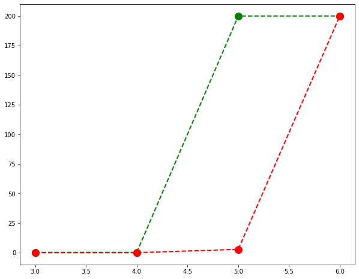

```python
plt.figure(figsize=(10,8))
plt.plot(y_table, res_depth_first, color='green', marker='o', linestyle='dashed', linewidth=2, markersize=12)
plt.plot(y_table, res_restart, color='red', marker='o', linestyle='dashed', linewidth=2, markersize=12)
plt.show()
```

# Problème de maximisation

#### Il suffit de changer le critère de supériorité de la persistence par un critère de maximisation :

```
mdl.add(count_different(S_prime) >= y) --> mdl.maximize(count_different(S_prime))
```

```python
def create_maximisation_problem(x):
    mdl = CpoModel(name='Persistance Multiplicative Maximisation of Persistence')
    E = mdl.integer_var(0, 10**x-1, "E") # E takes values between 0 and (10**x)-1
    S_prime = mdl.integer_var_list(Erdös_bound,0,10**x-1,"S") # We introduce a variables list of S because we can't put constaints on functions list

    S = remplissage_S(E,mdl) # Functions list

    for i in range(Erdös_bound):
        mdl.add(S_prime[i]==S[i]) # Variables list
    mdl.maximize(count_different(S_prime))
    return(mdl,E,S_prime)

def solve_maximisation_problem(x,method):
    mdl,E,S_prime = create_maximisation_problem(x)
    # Uncomment to display the first solution found
    sol = mdl.solve(TimeLimit= 200, SearchType=method, LogVerbosity='Quiet')
    if (sol.get_solve_status()!="Infeasible") :
        print ("The problem is satisfiable")
        # Print the solution
        value_of_E = sol[E]
        print ("Value of E is " ,  value_of_E)
        value_of_S = [sol[S_prime[i]] for i in range(Erdös_bound)]
        print ("Value of S is " ,  value_of_S)
        print ("Length of S =" , len(value_of_S))
        print ("Persistence =" , len(set(value_of_S)))
    else :
        print ("No solution")
    return None
```

```python
x = 4
mdl,E,S_prime = create_maximisation_problem(x)
start = time.time()
solve_maximisation_problem(x,'Restart')
end = time.time() - start
print("Solving using Restart took :",np.round(end,2),"s")
```

```
The problem is satisfiable
Value of E is  8876
Value of S is  [2688, 768, 336, 54, 20, 2, 2, 2, 2, 2, 2, 2, 2, 2, 2, 2, 2, 2, 2, 2, 2, 2, 2, 2, 2, 2, 2]
Length of S = 27
Persistence = 6
Solving using Restart took : 200.07 s
```

```python
x = 5
mdl,E,S_prime = create_maximisation_problem(x)
start = time.time()
solve_maximisation_problem(x,'Restart')
end = time.time() - start
print("Solving using Restart took :",np.round(end,2),"s")
```

```
The problem is satisfiable
Value of E is  99994
Value of S is  [26244, 384, 96, 54, 20, 2, 2, 2, 2, 2, 2, 2, 2, 2, 2, 2, 2, 2, 2, 2, 2, 2, 2, 2, 2, 2, 2]
Length of S = 27
Persistence = 6
Solving using Restart took : 200.06 s
```

La limite de temps à 200 secondes est atteinte pour x=4 et x=5 avant que l'algorithme ait pu tester toutes les possibilités. Ainsi, il retourne les dernières solutions connues.  
Par exemple pour x=5, le nombre 99994 donne une persistence de 6 alors que le maximum est en réalité 68889 qui donne une persistence de 7.